# triact package for R: Analyzing the lying behavior of cows from accelerometer data

Michael Simmler, Stijn P. Brouwers

08 April, 2025

This vignette contains executable examples for the intended use of the R package *triact*. Most of the functionalities are presented with default parameters. We recommend that you also read the help pages to learn more about the many parameters that can be used to customize the behavior of the methods in *triact*. Furthermore, background and rationale of the implemented analyses are described in detail in the following publication:

> Simmler M., Brouwers S. P., 2024. *triact* package for R: Analyzing the lying behavior of cows from accelerometer data. PeerJ, 12:e17036. https://doi.org/10.7717/peerj.17036.

## Setup

Since *triact* is typically used with accelerometer data with sampling frequency of ≥1 Hz, it is advisable to set R’s global option `digits.secs` to >=1 in order to enable the printing of fractional seconds.

```r
options(digits.secs = 1)
```

Via the global option `triact_table` the type of tables returned by *triact* can be specified. Options are `"data.frame"` (the default), `"tibble"`, and `"data.table"`.

```r
options(triact_table = "data.frame")
```

## Getting help

All functionalities of the *triact* R package are documented on the help page of the `Triact` R6 class.

```r
?Triact
```

## Inspecting the example data

The triact R package includes two raw data files from triaxial accelerometers (MSR145, MSR Electronics, Switzerland) attached to the left hind leg of dairy cows. The sampling frequency was 5 Hz. Each file represents one day of recording of one cow.

```r
input_dir <-  system.file("extdata", package = "triact")

files <- list.files(input_dir)

print(files)
```

```
## [1] "cow01_5hz.csv" "cow02_5hz.csv"
```

Inspecting one of the files reveals a file header and the semicolon-separated data starting after the line with `"*Data`“. This is an example of what files imported by *triact* might look like. However, *triact* can handle any kind of delimiter-separated text files, with or without an arbitrary file header (which is ignored during import).

```r
cat(paste(readLines(file.path(input_dir, files[1]), n = 30), collapse = "\n"))
```

```
## *CREATOR
## msr_cutter.exe;[V6.06.02]
## msr2csv.exe;[V6.06.02]
##
## *STARTTIME
## 2021-06-29;06:00:00;
##
## *MODUL
## NAME;MSR314553;MSR314553;MSR314553
## *NAME
## NAME;6A;6A;6A
##
## ID;[C26113 V5.66];[C26113 V5.66];[C26113 V5.66]
##
## *CHANNEL
## TIME;ACC x;ACC y;ACC z
##
## *UNIT
## ;G;G;G
##
## *LIMITS
## ALARM;;;
## RECRD;;;
## LIMIT1;;;
## LIMIT2;;;
##
## *DATA
## 2021-06-29 06:00:00.055;-0.048;1.032;-0.063
## 2021-06-29 06:00:00.258;-0.048;1.000;-0.063
## 2021-06-29 06:00:00.461;-0.048;1.000;-0.063
```

## Importing data

### Importing from raw files

The typical *triact* workflow starts by creating a new object of the `Triact` class.

```r
my_triact <- Triact$new()
```

Acceleration data is then imported into the `Triact` object (here named ‘my_triact’). The `$load_files()` method can be used to import any raw data files, which are delimiter-separated text files. If you are starting with a new file format you may want to select one or a few (small) files to find out how to specify the method’s argument to enable correct import from the file(s). Once this is done, you move on to process all your files. Examine your file format in a plain text editor or in R (as above).

```r
my_triact$load_files(input = input_dir,
                     id_substring = c(1, 5),
                     timeFwdUpRight_cols = c(1, -2, 3, -4),
                     time_format = "%Y-%m-%d %H:%M:%OS",
                     tz = "Europe/Zurich",
                     skip = "DATA",
                     sep = ";",
                     header = FALSE,
                     dec = ".")
```

The parameters as used above in the call of `$load_files()` have the following effects:

[figure not shown]

**(a)** Axis directions of the MSR145 accelerometer (MSR Electronics, Switzerland). **(b)** Directions as used in the *triact* R package. Shown is the situation with the accelerometer on the outside of the left hind leg as used to collect the example data.

Of the optional arguments that specify details about your file format, you may not need to specify many, because by default most of them are inferred from the data. In the case of the example data, you can reduce the arguments to:

```r
my_triact$load_files(input = input_dir,
                     id_substring = c(1, 5),
                     timeFwdUpRight_cols = c(1, -2, 3, -4),
                     skip = "DATA")
```

Once the data has been imported, you can use the `$data’ field to inspect the imported raw data and (later) added analyses at any time during the workflow.

```r
head(my_triact$data)
```

| id | time | acc_fwd | acc_up | acc_right |
| --- | --- | --- | --- | --- |
| cow01 | 2021-06-29 06:00:00.0 | 0.048 | 1.032 | 0.063 |
| cow01 | 2021-06-29 06:00:00.2 | 0.048 | 1.000 | 0.063 |
| cow01 | 2021-06-29 06:00:00.4 | 0.048 | 1.000 | 0.063 |
| cow01 | 2021-06-29 06:00:00.6 | 0.048 | 1.032 | 0.063 |
| cow01 | 2021-06-29 06:00:00.8 | 0.048 | 1.032 | 0.031 |
| cow01 | 2021-06-29 06:00:01.0 | 0.079 | 1.032 | 0.031 |

```r
str(my_triact$data)
```

```
## 'data.frame':    354462 obs. of  5 variables:
##  $ id       : Factor w/ 2 levels "cow01","cow02": 1 1 1 1 1 1 1 1 1 1 ...
##  $ time     : POSIXct, format: "2021-06-29 06:00:00.0" "2021-06-29 06:00:00.2" ...
##  $ acc_fwd  : num  0.048 0.048 0.048 0.048 0.048 0.079 0.048 0.048 0.079 0.079 ...
##  $ acc_up   : num  1.03 1 1 1.03 1.03 ...
##  $ acc_right: num  0.063 0.063 0.063 0.063 0.031 0.031 0.031 0.031 0.031 0.031 ...
```

**⚠️ Warning**

Correct mapping of your data to the body relative direction as used in *triact* is necessary for correct determination of the lying/standing posture and the lying laterality (lying side). Therefore, special care should be taken when specifying the parameter `timeFwdUpRight_cols`.

If you are unsure of the directions of your accelerometer’s XYZ data, you can determine them by experimentation. If the axis in question is pointing up, it should measure +1 *g* at rest. Note that accelerometers measure *proper acceleration* which is relative to free fall, so the gravitational component points skywards (reaction force of the ground).

**ℹ NOTE 1**

If you suspect that you have accidentally mounted some of your accelerometers 180° rotated in the sagittal plane, but you don’t know which raw data files are affected, you should call the `$check_orientation()` method after loading the data into the `Triact` object. This method will identify such “upside down” data and correct it accordingly by multiplying the *up* and *forward* axes by -1.

**ℹ NOTE 2**

You can import multiple files from the same cow, i.e., multiple files with the same id as extracted from file names according to what you specify via the `id_substring` parameter. But the data with the same cow id must follow each other without gaps in time. If you have gaps, you should use unique ids for the time series without gaps, e.g. you may need to use the cow identifier in combination with the date as a unique id.

**ℹ NOTE 3**

It can take a long time to import many files. You can speed things up by setting the `parallel` parameter of `$load_files()` to > 1, which allows files to be read in parallel. See `?Triact` for more information.

### Importing from a data.frame

Alternatively to importing from raw data files with `load_files()`, you can read your files with your own routine and then use the `$load_table()` method to import a data.frame into the `Triact` object. Column names and data types of the data.frame must be exactly as described in `?Triact`. An example data.frame, `cows_5hz`, is provided by the *triact* package.

A description of the example data.frame can be found on its help page.

```r
?cows_5hz
```

```r
str(cows_5hz)
```

```
## 'data.frame':    354462 obs. of  5 variables:
##  $ id       : Factor w/ 2 levels "cow01","cow02": 1 1 1 1 1 1 1 1 1 1 ...
##  $ time     : POSIXct, format: "2021-06-29 06:00:00.0" "2021-06-29 06:00:00.2" ...
##  $ acc_fwd  : num  0.048 0.048 0.048 0.048 0.048 0.079 0.048 0.048 0.079 0.079 ...
##  $ acc_up   : num  1.03 1 1 1.03 1.03 ...
##  $ acc_right: num  0.063 0.063 0.063 0.063 0.031 0.031 0.031 0.031 0.031 0.031 ...
```

Create new `Triact` object and import `cows_5hz`.

```r
my_triact <- Triact$new()
```

```r
my_triact$load_table(cows_5hz)
```

## Adding analyses

Calling add_… methods triggers analyses of lying behavior and the calculation of proxies for the level of physical activity. The results of the analyses are obtained for each time point of your accelerometer data and added in new columns to the tabular data in the `Triact` object.

### Detecting standing and lying posture

The `$add_lying()` method performs the classification into lying and standing posture. The results are (silently) added to the data in the `Triact` object as a logical column named *lying*, where `TRUE` indicates lying and `FALSE` standing. Additionally, lying and standing bouts are uniquely numbered (per cow or ID) in column *bout_nr*.

```r
my_triact$add_lying()
```

```r
str(my_triact$data)
```

```
## 'data.frame':    354462 obs. of  7 variables:
##  $ id       : Factor w/ 2 levels "cow01","cow02": 1 1 1 1 1 1 1 1 1 1 ...
##  $ time     : POSIXct, format: "2021-06-29 06:00:00.0" "2021-06-29 06:00:00.2" ...
##  $ acc_fwd  : num  0.048 0.048 0.048 0.048 0.048 0.079 0.048 0.048 0.079 0.079 ...
##  $ acc_up   : num  1.03 1 1 1.03 1.03 ...
##  $ acc_right: num  0.063 0.063 0.063 0.063 0.031 0.031 0.031 0.031 0.031 0.031 ...
##  $ bout_nr  : num  1 1 1 1 1 1 1 1 1 1 ...
##  $ lying    : logi  FALSE FALSE FALSE FALSE FALSE FALSE ...
```

**ℹ NOTE**

The `$add_lying()` method comes with many parameters that allow you to tweak the underlying algorithm. With the default parameters, you can expect good results if your accelerometer sampling frequency is ≥1 Hz. See `?Triact` and Simmler & Brouwers (2024) for explanations.

### Detecting lying laterality

The `$add_side()` method performs the determination of lying laterality (lying side). The results are (silently) added to the data in the `Triact` object as a factor column named *side*, with levels ‘L’ (left) and ‘R’ (right). During standing posture, *side* is `NA` (not available). Crucial for correct determination of the lying side is the correct specification of which hind leg the accelerometer was mounted on (parameter `left_leg = TRUE` for left, or `FALSE` for right).

```r
my_triact$add_side(left_leg = TRUE)
```

```r
str(my_triact$data)
```

```
## 'data.frame':    354462 obs. of  8 variables:
##  $ id       : Factor w/ 2 levels "cow01","cow02": 1 1 1 1 1 1 1 1 1 1 ...
##  $ time     : POSIXct, format: "2021-06-29 06:00:00.0" "2021-06-29 06:00:00.2" ...
##  $ acc_fwd  : num  0.048 0.048 0.048 0.048 0.048 0.079 0.048 0.048 0.079 0.079 ...
##  $ acc_up   : num  1.03 1 1 1.03 1.03 ...
##  $ acc_right: num  0.063 0.063 0.063 0.063 0.031 0.031 0.031 0.031 0.031 0.031 ...
##  $ bout_nr  : num  1 1 1 1 1 1 1 1 1 1 ...
##  $ lying    : logi  FALSE FALSE FALSE FALSE FALSE FALSE ...
##  $ side     : Factor w/ 2 levels "L","R": NA NA NA NA NA NA NA NA NA NA ...
```

### Calculating proxies for the level of physical activity

The `$add_activity()` method performs the calculation of proxies for the level of physical activity of the cow(s). By default, the L2 norm of the vector of the dynamic body acceleration (DBA) is calculated. It is ‘adjusted’ to a value of zero during lying bouts (prefix *Adj*), i.e., periods when cows are lying are considered as ‘inactive’ by definition. The results are (silently) added to the data in the `Triact` object as numeric column named *AdjL2DBA*.

```r
my_triact$add_activity()
```

```r
str(my_triact$data)
```

```
## 'data.frame':    354462 obs. of  9 variables:
##  $ id       : Factor w/ 2 levels "cow01","cow02": 1 1 1 1 1 1 1 1 1 1 ...
##  $ time     : POSIXct, format: "2021-06-29 06:00:00.0" "2021-06-29 06:00:00.2" ...
##  $ acc_fwd  : num  0.048 0.048 0.048 0.048 0.048 0.079 0.048 0.048 0.079 0.079 ...
##  $ acc_up   : num  1.03 1 1 1.03 1.03 ...
##  $ acc_right: num  0.063 0.063 0.063 0.063 0.031 0.031 0.031 0.031 0.031 0.031 ...
##  $ bout_nr  : num  1 1 1 1 1 1 1 1 1 1 ...
##  $ lying    : logi  FALSE FALSE FALSE FALSE FALSE FALSE ...
##  $ side     : Factor w/ 2 levels "L","R": NA NA NA NA NA NA NA NA NA NA ...
##  $ AdjL2DBA : num  0.0453 0.032 0.032 0.0453 0.032 ...
```

**ℹ NOTE 1**

You can select several proxies for the level of physical activity, namely the L1 and L2 norms of DBA and Jerk. Use the `norm` and `dynamic_measure` parameters to do this. See Simmler & Brouwers (2024) for a discussion of these proxies.

**ℹ NOTE 2**

Calculating DBA-based proxies involves a filtering step that can be tuned with several parameters (see `?Triact`). With the default parameters, you can expect good results if your accelerometer sampling frequency is ≥1 Hz.

## Summarizing results

The $summarize… methods are used to summarize the analyses added to the `Triact` object per time period, representing either the standing/lying bouts or regular intervals, e.g. 1 h or 24 h.

### Summarizing per lying/standing bout

With `$summarize_bouts()` a summary is created for the individual lying and standing bouts, with duration, mean activity, and lying side (for a lying bout). There is a help page with a description of the output.

```r
?bout_summary
```

```r
bouts_summary <- my_triact$summarize_bouts()
```

In the output you can see that the first bout per cow is not completely observed (`startTime` is missing) and therefor NAs are returned for measures that depend on complete observation of the bout, e.g. duration.

```r
head(bouts_summary)
```

| id | bout_nr | startTime | endTime | duration | lying | side | meanAdjL2DBA |
| --- | --- | --- | --- | --- | --- | --- | --- |
| cow01 | 1 | NA | 2021-06-29 06:17:40.3 | NA | FALSE | NA | NA |
| cow01 | 2 | 2021-06-29 06:17:40.3 | 2021-06-29 07:07:16.3 | 49.59973 | TRUE | L | 0.0000000 |
| cow01 | 3 | 2021-06-29 07:07:16.3 | 2021-06-29 09:11:33.2 | 124.28202 | FALSE | NA | 0.2055579 |
| cow01 | 4 | 2021-06-29 09:11:33.2 | 2021-06-29 09:46:51.8 | 35.30990 | TRUE | R | 0.0000000 |
| cow01 | 5 | 2021-06-29 09:46:51.8 | 2021-06-29 12:44:45.8 | 177.90027 | FALSE | NA | 0.0839487 |
| cow01 | 6 | 2021-06-29 12:44:45.8 | 2021-06-29 14:18:29.8 | 93.73203 | TRUE | R | 0.0000000 |

If only the lying bouts are of interest, the `bout_type` parameter can be specified accordingly.

```r
bouts_summary <- my_triact$summarize_bouts(bout_type = "lying")
```

```r
head(bouts_summary)
```

[output not shown]

**ℹ NOTE**

When calling the `$summarize_bouts()` method with parameter `calc_for_incomplete = TRUE`, a complete summary is also returned for the incompletely observed bouts (first and last bout for each cow). It does this by simply assuming that the bouts were completely observed. Use this option with caution.

### Summarizing per regular intervals

With `$summarize_intervals()` the summary is obtained per regular intervals, by default per hour. There is a help page with a description of the output.

```r
?interval_summary
```

```r
int_summary <- my_triact$summarize_intervals()
```

The NAs in the output are a result of incompletely observed intervals (first and last interval of each cow). The NaN on the other hand do not indicate missing information: For example, if the cow was not standing in the interval, the mean activity during standing is not zero, but cannot be calculated (thus NaN, “not a number”).

```r
head(int_summary)
```

| id | startTime | centerTime | endTime | duration | durationStanding | durationLying | durationLyingLeft | durationLyingRight | meanAdjL2DBA | meanAdjL2DBALying | meanAdjL2DBAStanding |
| --- | --- | --- | --- | --- | --- | --- | --- | --- | --- | --- | --- |
| cow01 | 2021-06-29 06:00:00 | 2021-06-29 06:30:00 | 2021-06-29 07:00:00 | NA | NA | NA | NA | NA | NA | NA | NA |
| cow01 | 2021-06-29 07:00:00 | 2021-06-29 07:30:00 | 2021-06-29 08:00:00 | 59.99973 | 52.72786 | 7.271874 | 7.271874 | 0.00000 | 0.2353070 | 0 | 0.2677589 |
| cow01 | 2021-06-29 08:00:00 | 2021-06-29 08:30:00 | 2021-06-29 09:00:00 | 59.99975 | 59.99975 | 0.000000 | 0.000000 | 0.00000 | 0.1658021 | NaN | 0.1658021 |
| cow01 | 2021-06-29 09:00:00 | 2021-06-29 09:30:00 | 2021-06-29 10:00:00 | 60.00312 | 24.69323 | 35.309891 | 0.000000 | 35.30989 | 0.0483203 | 0 | 0.1174156 |
| cow01 | 2021-06-29 10:00:00 | 2021-06-29 10:30:00 | 2021-06-29 11:00:00 | 59.99975 | 59.99975 | 0.000000 | 0.000000 | 0.00000 | 0.1011610 | NaN | 0.1011610 |
| cow01 | 2021-06-29 11:00:00 | 2021-06-29 11:30:00 | 2021-06-29 12:00:00 | 59.99973 | 59.99973 | 0.000000 | 0.000000 | 0.00000 | 0.0601318 | NaN | 0.0601318 |

```r
str(int_summary)
```

```
## 'data.frame':    20 obs. of  12 variables:
##  $ id                  : Factor w/ 2 levels "cow01","cow02": 1 1 1 1 1 1 1 1 1 1 ...
##  $ startTime           : POSIXct, format: "2021-06-29 06:00:00" "2021-06-29 07:00:00" ...
##  $ centerTime          : POSIXct, format: "2021-06-29 06:30:00" "2021-06-29 07:30:00" ...
##  $ endTime             : POSIXct, format: "2021-06-29 07:00:00" "2021-06-29 08:00:00" ...
##  $ duration            : num  NA 60 60 60 60 ...
##  $ durationStanding    : num  NA 52.7 60 24.7 60 ...
##  $ durationLying       : num  NA 7.27 0 35.31 0 ...
##  $ durationLyingLeft   : num  NA 7.27 0 0 0 ...
##  $ durationLyingRight  : num  NA 0 0 35.3 0 ...
##  $ meanAdjL2DBA        : num  NA 0.2353 0.1658 0.0483 0.1012 ...
##  $ meanAdjL2DBALying   : num  NA 0 NaN 0 NaN NaN 0 0 0 NA ...
##  $ meanAdjL2DBAStanding: num  NA 0.268 0.166 0.117 0.101 ...
```

The intervals can be specified quite flexibly: In case of 30 min intervals and starting 10 min after the full hour you can specify `interval` and `lag_in_s` parameters accordingly.

```r
int_summary <- my_triact$summarize_intervals(interval = "30 min",
                                             lag_in_s = 10 * 60)
```

```r
head(int_summary)
```

| id | startTime | centerTime | endTime | duration | durationStanding | durationLying | durationLyingLeft | durationLyingRight | meanAdjL2DBA | meanAdjL2DBALying | meanAdjL2DBAStanding |
| --- | --- | --- | --- | --- | --- | --- | --- | --- | --- | --- | --- |
| cow01 | 2021-06-29 05:40:00 | 2021-06-29 05:55:00 | 2021-06-29 06:10:00 | NA | NA | NA | NA | NA | NA | NA | NA |
| cow01 | 2021-06-29 06:10:00 | 2021-06-29 06:25:00 | 2021-06-29 06:40:00 | 30.00157 | 7.671355 | 22.33021 | 22.33021 | 0 | 0.0339750 | 0 | 0.1328715 |
| cow01 | 2021-06-29 06:40:00 | 2021-06-29 06:55:00 | 2021-06-29 07:10:00 | 29.99817 | 2.728645 | 27.26952 | 27.26952 | 0 | 0.0559089 | 0 | 0.6146511 |
| cow01 | 2021-06-29 07:10:00 | 2021-06-29 07:25:00 | 2021-06-29 07:40:00 | 30.00157 | 30.001567 | 0.00000 | 0.00000 | 0 | 0.2705540 | NaN | 0.2705540 |
| cow01 | 2021-06-29 07:40:00 | 2021-06-29 07:55:00 | 2021-06-29 08:10:00 | 29.99818 | 29.998183 | 0.00000 | 0.00000 | 0 | 0.2059550 | NaN | 0.2059550 |
| cow01 | 2021-06-29 08:10:00 | 2021-06-29 08:25:00 | 2021-06-29 08:40:00 | 30.00155 | 30.001550 | 0.00000 | 0.00000 | 0 | 0.1735580 | NaN | 0.1735580 |

```r
str(int_summary)
```

```
## 'data.frame':    42 obs. of  12 variables:
##  $ id                  : Factor w/ 2 levels "cow01","cow02": 1 1 1 1 1 1 1 1 1 1 ...
##  $ startTime           : POSIXct, format: "2021-06-29 05:40:00" "2021-06-29 06:10:00" ...
##  $ centerTime          : POSIXct, format: "2021-06-29 05:55:00" "2021-06-29 06:25:00" ...
##  $ endTime             : POSIXct, format: "2021-06-29 06:10:00" "2021-06-29 06:40:00" ...
##  $ duration            : num  NA 30 30 30 30 ...
##  $ durationStanding    : num  NA 7.67 2.73 30 30 ...
##  $ durationLying       : num  NA 22.3 27.3 0 0 ...
##  $ durationLyingLeft   : num  NA 22.3 27.3 0 0 ...
##  $ durationLyingRight  : num  NA 0 0 0 0 ...
##  $ meanAdjL2DBA        : num  NA 0.034 0.0559 0.2706 0.206 ...
##  $ meanAdjL2DBALying   : num  NA 0 0 NaN NaN NaN NaN 0 0 NaN ...
##  $ meanAdjL2DBAStanding: num  NA 0.133 0.615 0.271 0.206 ...
```

With `bouts = TRUE` you can request that, additionally, the bouts within the intervals are summarized. For measures such as the number of lying bouts or mean lying bout duration, a weighted mean is calculated with the weights being the proportion of the individual bout overlapping with the respective interval. With `side = TRUE` you can additionally request a differentiation of all results by lying side. Again, NAs in the output are a result of incompletely observed intervals (first and last interval of each cow). Additionally you will sometimes find NAs in the output for summaries of bouts per interval (`bouts = TRUE`) that result from incompletely observed bouts (first and last bout for each cow). As bouts can span several intervals, this can affect more than just the first and the last interval. Please be aware about the difference between NA and NaN described above.

```r
int_summary <- my_triact$summarize_intervals(bouts = TRUE,
                                             side = TRUE)
```

```r
str(int_summary)
```

```
## 'data.frame':    20 obs. of  22 variables:
##  $ id                         : Factor w/ 2 levels "cow01","cow02": 1 1 1 1 1 1 1 1 1 1 ...
##  $ startTime                  : POSIXct, format: "2021-06-29 06:00:00" "2021-06-29 07:00:00" ...
##  $ centerTime                 : POSIXct, format: "2021-06-29 06:30:00" "2021-06-29 07:30:00" ...
##  $ endTime                    : POSIXct, format: "2021-06-29 07:00:00" "2021-06-29 08:00:00" ...
##  $ duration                   : num  NA 60 60 60 60 ...
##  $ durationStanding           : num  NA 52.7 60 24.7 60 ...
##  $ durationLying              : num  NA 7.27 0 35.31 0 ...
##  $ durationLyingLeft          : num  NA 7.27 0 0 0 ...
##  $ durationLyingRight         : num  NA 0 0 35.3 0 ...
##  $ meanAdjL2DBA               : num  NA 0.2353 0.1658 0.0483 0.1012 ...
##  $ meanAdjL2DBALying          : num  NA 0 NaN 0 NaN NaN 0 0 0 NA ...
##  $ meanAdjL2DBAStanding       : num  NA 0.268 0.166 0.117 0.101 ...
##  $ meanAdjL2DBALyingLeft      : num  NA 0 NaN NaN NaN NaN NaN NaN 0 NA ...
##  $ meanAdjL2DBALyingRight     : num  NA NaN NaN 0 NaN NaN 0 0 0 NA ...
##  $ nBoutsStanding             : num  NA 0.424 0.483 0.167 0.337 ...
##  $ nBoutsLying                : num  NA 0.147 0 1 0 ...
##  $ nBoutsLyingLeft            : num  NA 0.147 0 0 0 ...
##  $ nBoutsLyingRight           : num  NA 0 0 1 0 ...
##  $ wMeanDurationStandingBout  : num  NA 124 124 148 178 ...
##  $ wMeanDurationLyingBout     : num  NA 49.6 NaN 35.3 NaN ...
##  $ wMeanDurationLyingBoutLeft : num  NA 49.6 NaN NaN NaN ...
##  $ wMeanDurationLyingBoutRight: num  NA NaN NaN 35.3 NaN ...
```

**ℹ NOTE**

When calling the `$summarize_intervals()` method with parameter `calc_for_incomplete = TRUE`, a complete summary will also be returned for the incompletely observed intervals (first and last interval for each cow) and for any parameter using information of incompletely observed bouts (which can affect more than just the first and last interval). It does this by simply assuming that intervals and bouts were completely observed. Use this option with caution.

## Visualizing results

The *triact* package does not come with visualization capabilities. But the data can easily be accessed and plotted with base R or packages dedicated to graphics (e.g. ggplot2). The following example shows how to access the data of a single cow (here with id “cow01”) and to visualize the lying behavior.

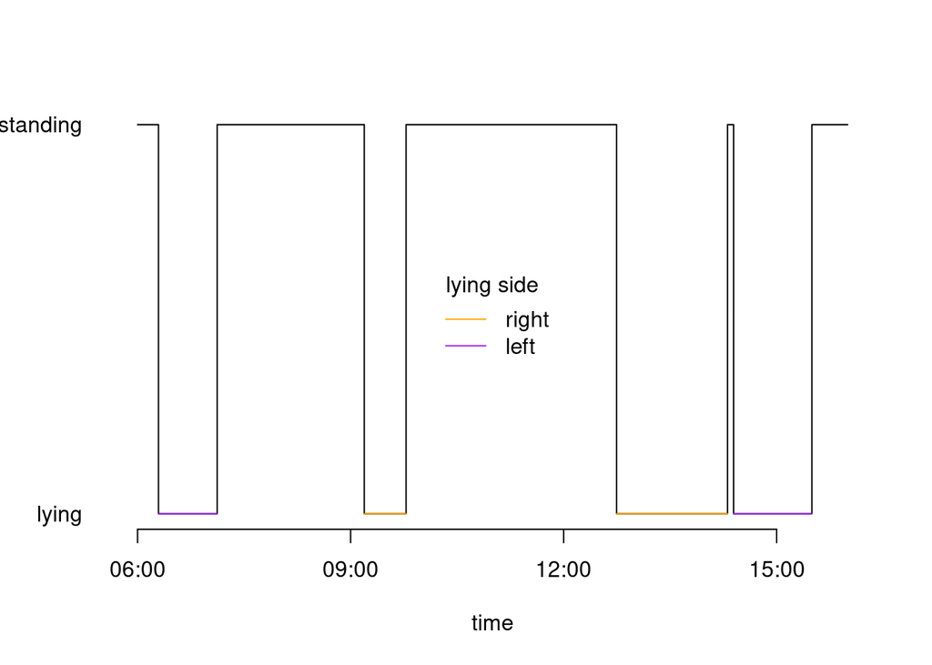

```r
cow_id = "cow01"

data_01 <- my_triact$data[my_triact$data$id == cow_id, ]

plot(!lying ~ time, data = data_01,
     type = "l", ylab = "", yaxt = "n", bty = "n")

lines(ifelse(side == "R", 0, NA) ~ time, data = data_01, col = "orange")
lines(ifelse(side == "L", 0, NA) ~ time, data = data_01, col = "purple")

axis(2, at = c(0, 1),
     labels = c("lying", "standing"),
     las = 1,
     lwd = 0)

legend(x = "center",
       legend = c("right", "left"),
       col = c("orange", "purple"),
       lwd = 1, bty = "n", title = "lying side")
```

## Extracting posture transitions

Using `$extract_liedown()` and `$extract_standup()`, the raw acceleration data (and added analyses) of the posture transitions, i.e., lying-to-standing and standing-to-lying, can be extracted.

With default parameters, only the time of the transition, bout nr of the lying bout, and lying side (if available) are returned.

```r
st_ups <- my_triact$extract_standup()
```

```r
print(st_ups)
```

```
##      id                time bout_nr side
## 1 cow01 2021-06-29 07:07:16       2    L
## 2 cow01 2021-06-29 09:46:51       4    R
## 3 cow01 2021-06-29 14:18:29       6    R
## 4 cow01 2021-06-29 15:29:43       8    L
## 5 cow02 2021-06-29 07:07:26       1    R
## 6 cow02 2021-06-29 14:38:00       3    R
## 7 cow02 2021-06-29 15:43:00       5    L
```

When specifying ‘sec_before’ and ’sec_after`, time series around the exact moment of posture transition as detected by *triact* are returned. The result is a list with tables (one table per posture transition).

```r
l_downs <- my_triact$extract_liedown(sec_before = 3, sec_after = 3)
```

```r
head(l_downs[[1]])
```

| id | time | acc_fwd | acc_up | acc_right | bout_nr | lying | side | AdjL2DBA |
| --- | --- | --- | --- | --- | --- | --- | --- | --- |
| cow01 | 2021-06-29 06:17:37.5 | 0.238 | 0.968 | 0.031 | 1 | FALSE | NA | 0.0992975 |
| cow01 | 2021-06-29 06:17:37.7 | 0.175 | 0.968 | 0.031 | 1 | FALSE | NA | 0.0989798 |
| cow01 | 2021-06-29 06:17:37.9 | 0.175 | 1.000 | 0.000 | 1 | FALSE | NA | 0.1327027 |
| cow01 | 2021-06-29 06:17:38.1 | 0.143 | 1.000 | 0.063 | 1 | FALSE | NA | 0.0940053 |
| cow01 | 2021-06-29 06:17:38.3 | 0.143 | 1.000 | 0.063 | 1 | FALSE | NA | 0.0940053 |
| cow01 | 2021-06-29 06:17:38.5 | 0.111 | 1.032 | 0.031 | 1 | FALSE | NA | 0.1481789 |